# Lab 3A: Regression (Easy)

### 2. Create Training and Test Sets

1. Set the random seed to make randomness reproducable

```r
set.seed(42)
```

2. Randomly sample 100 of 150 row indexes

```r
indexes <- sample(
  x = 1:150,
  size = 100)
```

3. Create training set from indexes

```r
train <- iris[indexes, ]
```

4. Create test set from remaining indexes

```r
test <- iris[-indexes, ]
```

### 3. Predict with Simple Linear Regression

1. Create a simple linear regression model

```r
simpleModel <- lm(
  formula = Petal.Width ~ Petal.Length,
  data = train)
```

2. Draw simple linear regression line on plot

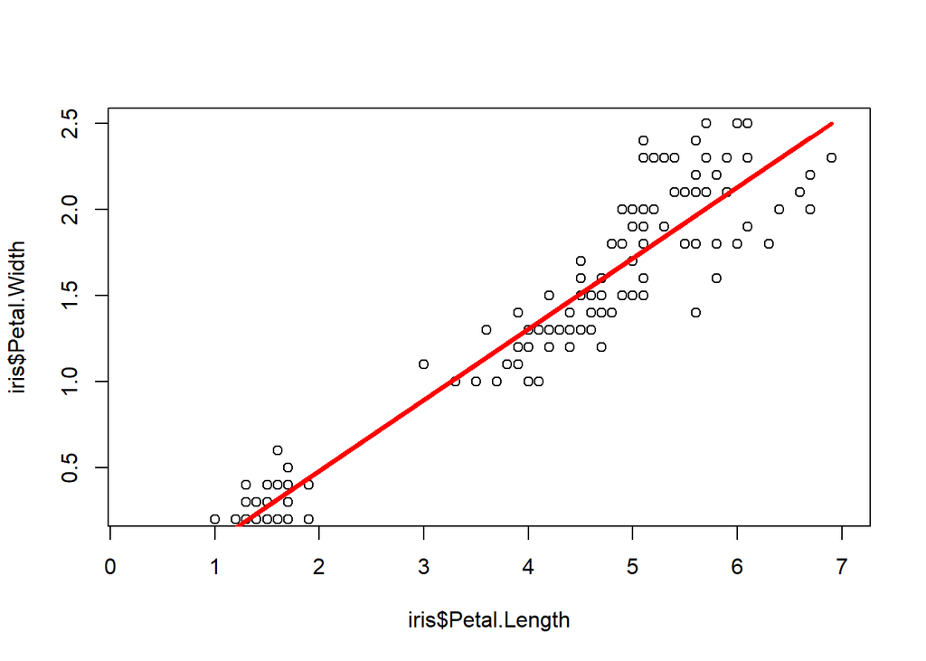

```r
plot(
  x = iris$Petal.Length,
  y = iris$Petal.Width,
  xlim = c(0.25, 7),
  ylim = c(0.25, 2.5))

lines(
  x = train$Petal.Length,
  y = simpleModel$fitted,
  col = "red",
  lwd = 3)
```

3. Summarize the model

```r
summary(simpleModel)
```

```
##
## Call:
## lm(formula = Petal.Width ~ Petal.Length, data = train)
##
## Residuals:
##      Min       1Q   Median       3Q      Max
## -0.56627 -0.12399 -0.01245  0.13209  0.64001
##
## Coefficients:
##              Estimate Std. Error t value Pr(>|t|)
## (Intercept)  -0.34411    0.04996  -6.888 5.47e-10 ***
## Petal.Length  0.41257    0.01192  34.617  < 2e-16 ***
## ---
## Signif. codes:  0 '***' 0.001 '**' 0.01 '*' 0.05 '.' 0.1 ' ' 1
##
## Residual standard error: 0.2119 on 98 degrees of freedom
## Multiple R-squared:  0.9244, Adjusted R-squared:  0.9236
## F-statistic:  1198 on 1 and 98 DF,  p-value: < 2.2e-16
```

4. Create predictions with test set

```r
simplePredictions <- predict(
  object = simpleModel,
  newdata = test)
```

5. Plot predictions on scatterplot

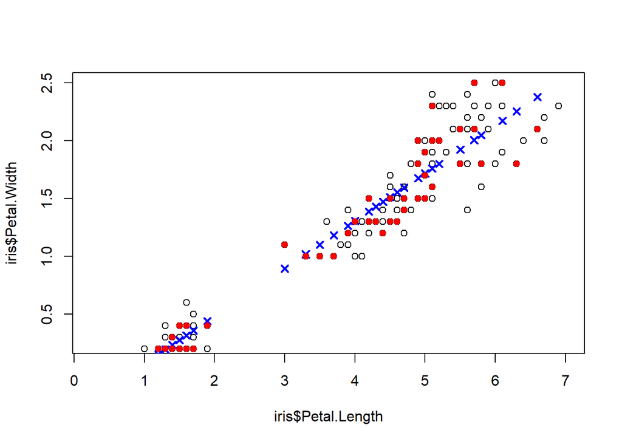

```r
plot(
  x = iris$Petal.Length,
  y = iris$Petal.Width,
  xlim = c(0.25, 7),
  ylim = c(0.25, 2.5))

points(
  x = test$Petal.Length,
  y = simplePredictions,
  col = "blue",
  pch = 4,
  lwd = 2)

points(
  x = test$Petal.Length,
  y = test$Petal.Width,
  col = "red",
  pch = 16)
```

6. Compute Root Mean Squared Error for simple linear predictions

```r
simpleRMSE <- sqrt(mean((test$Petal.Width - simplePredictions)^2))
```

7. Inspect RMSE

```r
print(simpleRMSE)
```

```
## [1] 0.1960294
```

### 4. Predict with Multiple Regression

1. Create multiple linear regression model

```r
multipleModel <- lm(
  formula = Petal.Width ~ .,
  data = train)
```

2. Inspect the model

```r
summary(multipleModel)
```

```
##
## Call:
## lm(formula = Petal.Width ~ ., data = train)
##
## Residuals:
##      Min       1Q   Median       3Q      Max
## -0.61056 -0.08035 -0.01463  0.09287  0.45260
##
## Coefficients:
##                   Estimate Std. Error t value Pr(>|t|)
## (Intercept)       -0.28170    0.22889  -1.231 0.221503
## Sepal.Length      -0.10639    0.05639  -1.887 0.062271 .
## Sepal.Width        0.19705    0.05894   3.343 0.001189 **
## Petal.Length       0.26896    0.06718   4.004 0.000125 ***
## Speciesversicolor  0.55074    0.17149   3.211 0.001808 **
## Speciesvirginica   0.92273    0.23227   3.973 0.000139 ***
## ---
## Signif. codes:  0 '***' 0.001 '**' 0.01 '*' 0.05 '.' 0.1 ' ' 1
##
## Residual standard error: 0.1788 on 94 degrees of freedom
## Multiple R-squared:  0.9484, Adjusted R-squared:  0.9456
## F-statistic: 345.4 on 5 and 94 DF,  p-value: < 2.2e-16
```

3. Create predictions with test set

```r
multiplePredictions <- predict(
  object = multipleModel,
  newdata = test)
```

4. Plot predictions on scatterplot

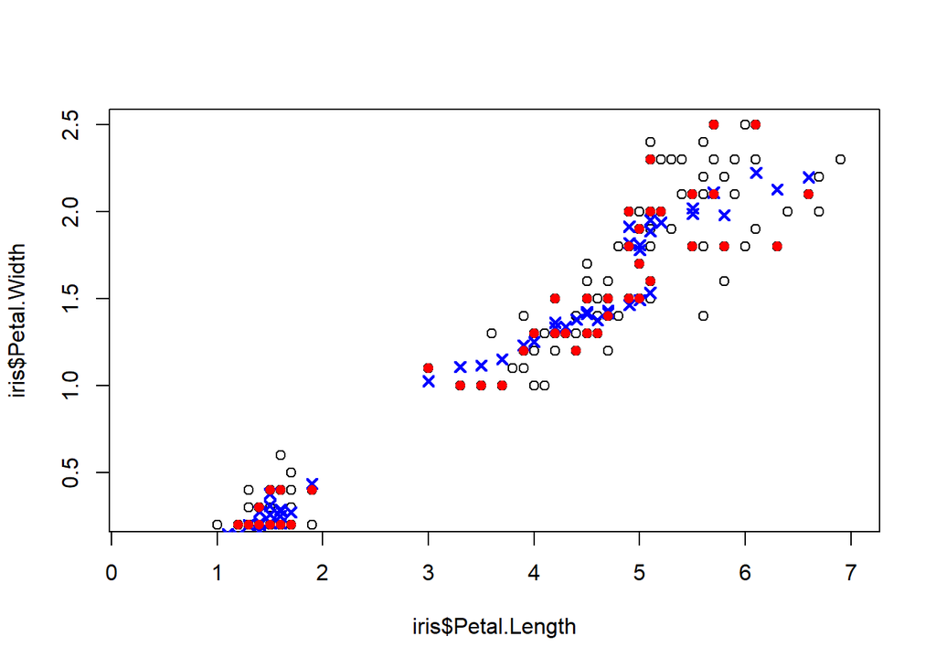

```r
plot(
  x = iris$Petal.Length,
  y = iris$Petal.Width,
  xlim = c(0.25, 7),
  ylim = c(0.25, 2.5))

points(
  x = test$Petal.Length,
  y = multiplePredictions,
  col = "blue",
  pch = 4,
  lwd = 2)

points(
  x = test$Petal.Length,
  y = test$Petal.Width,
  col = "red",
  pch = 16)
```

5. Compute RMSE for model

```r
multipleRMSE <- sqrt(mean((test$Petal.Width - multiplePredictions)^2))
```

6. Display RMSE for model

```r
print(multipleRMSE)
```

```
## [1] 0.144159
```

### 5. Predict with Neural Network Regression

1. Create normalization function

```r
normalize <- function(x) {
  (x - min(x)) / (max(x) - min(x)) - 0.5
}
```

2. Create denormalize function

```r
denormalize <- function(x, y) {
  ((x + 0.5) * (max(y) - min(y))) + min(y)
}
```

3. Scale iris data set

```r
scaledIris <- data.frame(
  Sepal.Length = normalize(iris$Sepal.Length),
  Sepal.Width = normalize(iris$Sepal.Width),
  Petal.Length = normalize(iris$Petal.Length),
  Petal.Width = normalize(iris$Petal.Width),
  Species = iris$Species)
```

4. Create training set from indexes

```r
scaledTrain <- scaledIris[indexes, ]
```

5. Create test set from remaining indexes

```r
scaledTest <- scaledIris[-indexes, ]
```

6. Load the neural network package

```r
library(nnet)
```

7. Create a neural network regressor

```r
neuralRegressor <- nnet(
  formula = Petal.Width ~ .,
  data = scaledTrain,
  linout = TRUE,
  skip = TRUE,
  size = 4,
  decay = 0.0001,
  maxit = 500)
```

8. Load neural network tools

```r
library(NeuralNetTools)
```

9. Plot the neural network

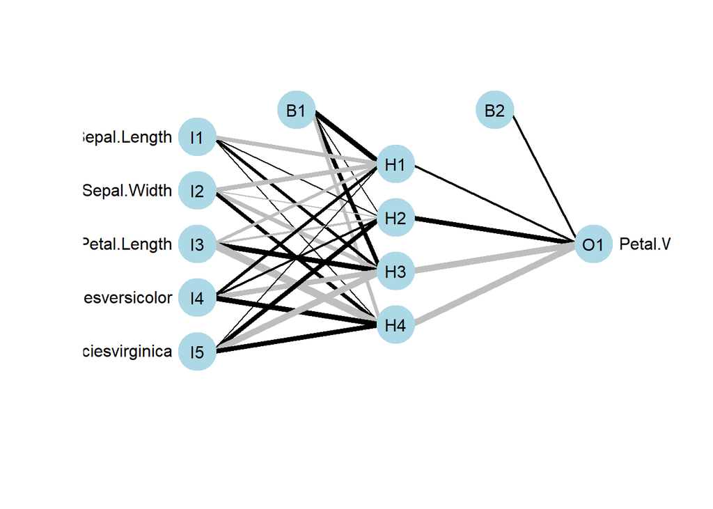

```r
plotnet(neuralRegressor)
```

10. Predict new values

```r
scaledPredictions <- predict(
  object = neuralRegressor,
  newdata = scaledTest)
```

11. Denormalize predictions

```r
neuralPredictions <- denormalize(
  x = scaledPredictions,
  y = iris$Petal.Width)
```

12. Plot predictions on scatterplot

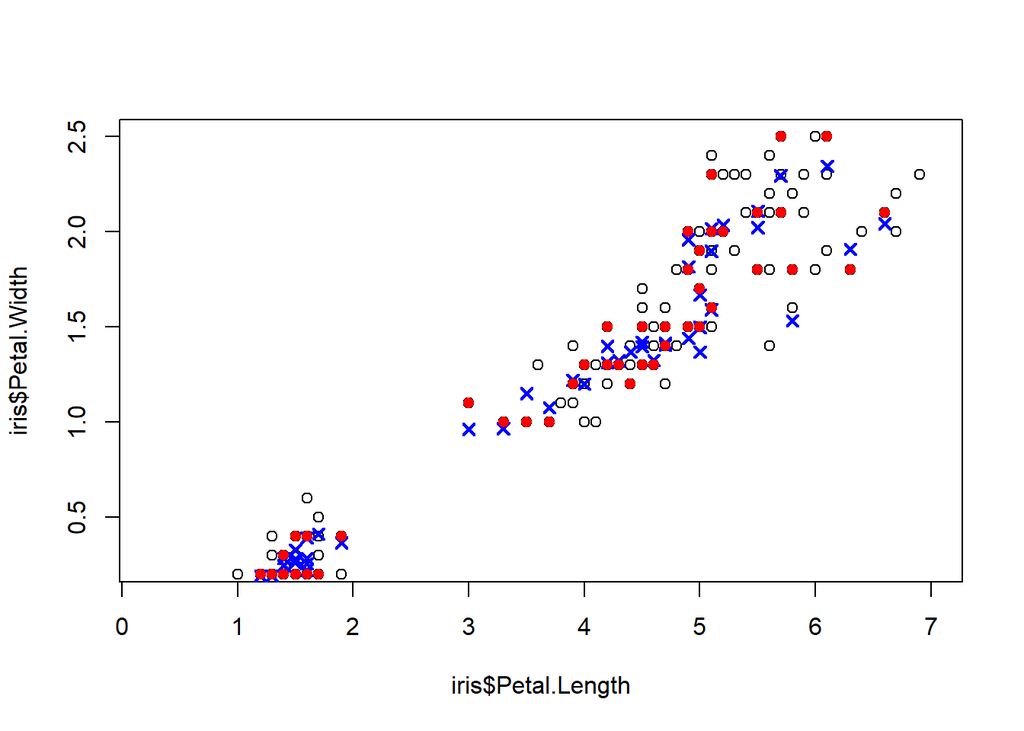

```r
plot(
  x = iris$Petal.Length,
  y = iris$Petal.Width,
  xlim = c(0.25, 7),
  ylim = c(0.25, 2.5))

points(
  x = test$Petal.Length,
  y = neuralPredictions,
  col = "blue",
  pch = 4,
  lwd = 2)

points(
  x = test$Petal.Length,
  y = test$Petal.Width,
  col = "red",
  pch = 16)
```

13. Compute RMSE for neural regression

```r
neuralRMSE <- sqrt(mean((test$Petal.Width - neuralPredictions)^2))
```

14. Display RMSE for neural regression

```r
print(neuralRMSE)
```

```
## [1] 0.1364079
```

### 6. Evaluate Regression Models

1. Compare the RMSE for all three models

```r
print(simpleRMSE)
```

```
## [1] 0.1960294
```

```r
print(multipleRMSE)
```

```
## [1] 0.144159
```

```r
print(neuralRMSE)
```

```
## [1] 0.1364079
```